# Recommender Systems

Jawaid Hakim

2022-11-02

# 1 Task

Your task is to analyze an existing recommender system that you find interesting.

## 1.1 Scenario Design analysis

> Perform a Scenario Design analysis as described below. Consider whether it makes sense for your selected recommender system to perform scenario design twice, once for the organization (e.g. Amazon.com) and once for the organization’s customers.

Pair programming is a software development practice in which developers pair up. In it’s purest form it is an agile software development technique in which two programmers work together at one workstation. One, the driver, writes code while the other, the observer or navigator, reviews each line of code as it is typed in. The two programmers switch roles frequently. With remote teams becoming the norm, the *one workstation* requirement is virtual.

The theoretical benefits of pair programming, in a nutshell, are that it is supposed to produce better outcomes that either developer would on her own. Problems and defects are identified earlier and solutions are discussed and evaluated up-front. In practice, pair programming is not easy to practice. For instance, it is very difficult to pair up with geographically distributed team members.

Enter [Github Copilot](https://github.com/features/copilot). This offering is centered squarely on the development community. Think of it as your paired developer who is available whenever you need assistance and who is an expert in your favorite languages and all the languages that you don’t know! Copilot is based on [Open AI Codex](https://openai.com/blog/openai-codex/) that tranlates natual language to code in more than a dozed programming languages.

Developers spend a considerable amount of their time writing boilerplate code. Although nowadays there are excellent libraries and frameworks that alleviate a lot of this grunge work but there is still a tremendous volume of boilerplate code being written. Bugs and defects are invariably introduced that consume mindshare and development cycles.

Copilot uses AI to suggest code and entire functions across a wide variety of languages. Trained on billions of lines of code (from Github of course) across a spectrum of languages, Copilot turns natural language prompts and cues into coding suggestions. It promises to reduce development cycles, improve software quality, and provide guidance on best practices. It can also a tool that beginner coders can use to explore programming.

Copilot integrates with IDEs and provides inp-line code suggestions. For example, when a python developer starts defining a function, Copilot suggests the function body. Notice, in this case the code is suggested based simply on the function name. Since Copilot has seen billions of lines of code and good developers use established naming conventions it is able to make highly relevant code suggestions.

[figure not shown]

It can make a number of suggestions and developer can see them by clicking Next in VS Code:

[figure not shown]

When developer sees a suggestion that’s to her liking she clicks Accept:

[figure not shown]

# 2 Reverse Engineer

> Attempt to reverse engineer what you can about the site, from the site interface and any available information that you can find on the Internet or elsewhere.

You have to signup to use Copilot. Signup requires a Github account. Once signed up all one needs is a IDE that has a Copilot plugin. At current time there are plugins for JetBrains IDEs, Neovim, VS Code, and Visual Studio.

I tried using VS Code with R but it is not a stable development environment. The Copilot component was working fine though and it was suggesting R code snippets as I was coding. Other development environments, like Python with VS Code, are more robust. Here is a Jupyter Notebook, where I entered the name of a function (sort_array) and parameter type hint (str) and Copilot suggested the function body. Based on my hints the Copilot suggestion was astonishing:

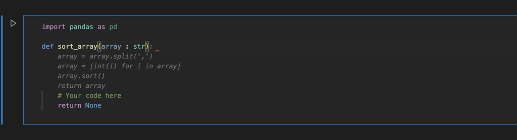

## 2.1 Improvement

> Include specific recommendations about how to improve the site’s recommendation capabilities going forward

Copilot is an astonishing display of using NLP to build a cool developer productivity service. I can see a service like Copilot becoming an essential and ubiquitous part of a developer’s toolkit. Although Copilot is owned by Microsoft, hence early integrations with VS Code and Visual Studio, one hopes that the service will eventually integrate with a wider set of IDEs (e.g. RStudio, Eclipse).

Copilot needs to provide greater transparency of exactly what are being scanned for training the AI model, potential security holes [[CCS]](https://cyber.nyu.edu/2021/10/15/ccs-researchers-find-github-copilot-generates-vulnerable-code-40-of-the-time/) and copyright issues [[FOSSA]](https://fossa.com/blog/analyzing-legal-implications-github-copilot/), etc.